# Informe_PG1

Author

-del Castillo Collanatos Alonso Matias -Flores Ayllon Luis Alberto -Jerusalen Zelaya Jorge -Liang Corrales Renzo Chen Heng -Zamudio Raez Trilce

Published

May 28, 2025

## 1 1. Tema

*Influencia de las redes sociales en el estilo de vida de los jóvenes universitarios*

## 2 2. Objetivo General

Analizar el uso de las redes sociales en el público joven universitario y su impacto en su estilo de vida (horas de sueño, horas de estudio, horas de ejercicio, rendimiento académico, actividades extracurriculares).

## 3 3. Objetivos Específicos

-Estudiar la relación entre la frecuencia de revisión de redes sociales y el tiempo promedio de atención sostenida sin distracciones (variable numérica).

-Evaluar si existe una diferencia en el desempeño académico entre las personas que duermen más y las que duermen menos.

-Evaluar el desempeño académico de los estudiantes con respecto al tipo de contenido que consumen.

-Analizar la diferencia en el promedio de horas de estudio diario entre estudiantes de universidades públicas y privadas. -Estudiar como el tipo de red social mas utilizada se relaciona con la satisfacción académica y social del estudiante.

## 4 4. Contexto

### 4.1 4.1 Población Objetivo

Estudiantes universitarios que estén matriculados en alguna institución de educación superior durante el ciclo académico 2025-I. La población está formada por alumnos de diferentes carreras y ciclos de estudio (desde el primer hasta el último ciclo), que usen redes sociales con frecuencia. Se considerarán estudiantes de universidades tanto públicas como privadas.

## 5 4.2 Tipo de Muestreo

El muestreo por conveniencia es una técnica de muestreo no probabilística donde las muestras de la población se seleccionan solo porque están convenientemente disponibles para el investigador. De acuerdo a nuestro tema encuestamos aleatoriamente a los estudiantes universitarios que están más accesibles o disponibles, ya sea por cercanía dentro del campus, facilidad de contacto, pertenecer al mismo entorno académico.

## 6 4.3 Recolección de Datos

Crearemos un cuestionario con preguntas claves que nos ayuden a recolectar los datos necesarios. Este formulario lo llenaran los universitarios del ciclo 2025-I, con el fin de obtener los datos necesarios para cada variable y estas nos ayuden a responder los objetivos generales.

## 7 4.4 Variables

Variable Tipo de variable Descripción de cada variable

Hora promedio de estudio Numérica_Continua Número promedio de horas que un estudiante dedica al estudio diariamente.

Promedio de notas del último semestre Numérica_Continua Promedio numérico de calificaciones obtenidas por el estudiante durante el último semestre académico.

Horas dormidas Numérica_Discreta Número de horas de sueño que reporta tener el estudiante por noche.

Tipo de contenido que consume Categórica_Nominal Tipo de contenido digital que el estudiante consume principalmente en redes sociales (Educación, Entretenimiento, Información, Socializar.).

Satisfacción académica Categórica_Ordinal Nivel de satisfacción con el rendimiento académico actual, expresado en una escala del 1 al 5.

Satisfacción social Categórica_Ordinal Nivel de satisfacción con la interacción social presencial con amigos o compañeros, en una escala del 1 al 5.

Tipo de universidad Categórica_Nominal Clasificación de la universidad a la que pertenece el estudiante: Pública o Privada.

Red social más usada Categórica_Nominal Red social que el estudiante utiliza con mayor frecuencia (WhatsApp, Instagram, TikTok, Facebbok, X(Twitter), Linkedin, Telegram, Discord, Otro).

## 8 5 Limpieza de datos

```r
library(readr)
library(dplyr)
library(ggplot2)
library(stringr)
library(tidyr)
library(ggplot2)
library(modeest)
library(reshape2)
library(DescTools)
DF = read_csv("bd_proyecto.csv")
Data_5 <- DF
Data_5
```

```
# A tibble: 1,307 × 41
   `Marca temporal`         `Nombre de usuario` Grupo de la sección …¹ `Grupo 1`
   <chr>                    <chr>               <chr>                  <chr>
 1 2025/04/17 2:30:11 p. m… paul.valer@utec.ed… Grupo 3                <NA>
 2 2025/04/17 2:33:48 p. m… u20231f309@gmail.c… Grupo 1                Adrian
 3 2025/04/17 2:34:05 p. m… luciana.yangali@ut… Grupo 1                Adrian
 4 2025/04/17 2:34:42 p. m… respaldizaf@gmail.… Grupo 1                Adrian
 5 2025/04/17 2:35:05 p. m… ricardo.jose.yap.m… Grupo 9                <NA>
 6 2025/04/17 2:39:18 p. m… fsakiya@gmail.com   Grupo 1                Adrian
 7 2025/04/17 2:40:38 p. m… paul.pando@utec.ed… Grupo 4                <NA>
 8 2025/04/17 2:43:42 p. m… samir.mena@utec.ed… Grupo 1                Adrian
 9 2025/04/17 2:43:47 p. m… samuellaosanchez@g… Grupo 1                Adrian
10 2025/04/17 2:44:27 p. m… octaviogallo1012@g… Grupo 9                <NA>
# ℹ 1,297 more rows
# ℹ abbreviated name: ¹`Grupo de la sección 5 que realiza la encuesta.`
# ℹ 37 more variables: `Grupo 2` <chr>, `Grupo 3` <chr>, `Grupo 4` <chr>,
#   `Grupo 5` <chr>, `Grupo 6` <chr>, `Grupo 7` <chr>, `Grupo 8` <chr>,
#   `Grupo 9` <chr>, `1. ¿Cuál es tu edad?` <dbl>,
#   `2. ¿Cuál es tu sexo?` <chr>,
#   `3. ¿Estas en una universidad privada o pública?` <chr>, …
```

```r
nueva_data <- Data_5[, c(16,23,29,27,32,39,33,15,28)]
Grupo5_renombrado <- nueva_data %>%
  rename(
    universidad = `3. ¿Estas en una universidad privada o pública?`,
    horas_estudio = `4. ¿Cuántas horas en promedio al día estudias?`,
    promedio_ponderado = `7. ¿Cuál fue tu promedio ponderado el ciclo pasado?`,
    horas_sueno = `11. ¿Cuántas horas duermes aproximadamente por noche?`,
    red_social_mas_usada = `12. ¿Qué plataforma de red social es la que más usas?`,
    tiempo_sin_revisar_el_celular = `13. ¿Cuál es el tiempo máximo que puedes estar sin revisar tus redes sociales?`,
    satisfaccion_social = `17. ¿Qué tan satisfecho estás con tu interacción social presencial con amigos o compañeros en tu centro de estudio y/o trabajo?`,
    satisfaccion_academica = `24. ¿Qué tan satisfecho(a) estás con tu rendimiento académico actual?`,
    tipo_contenido = `16. ¿Qué tipo de contenido consumes principalmente en redes sociales?`

  )
copia1<-Grupo5_renombrado
copia1
```

```
# A tibble: 1,307 × 9
   horas_estudio promedio_ponderado tiempo_sin_revisar_el_celular horas_sueno
           <dbl> <chr>              <chr>                               <dbl>
 1           2   14.2               2                                       8
 2           2   17                 5.3                                     8
 3           4   12                 5                                       6
 4           3.5 15.9               1.5                                     6
 5           3   16                 4                                       5
 6           1.5 16.17              1                                       7
 7           2   14.4               0.5                                     7
 8           4   13.57              12                                      8
 9           3   18                 3                                       6
10          10   18                 4                                       5
# ℹ 1,297 more rows
# ℹ 5 more variables: tipo_contenido <chr>, satisfaccion_academica <dbl>,
#   satisfaccion_social <dbl>, universidad <chr>, red_social_mas_usada <chr>
```

## 9 5.1 Cambio de nombre

```r
colnames(copia1)
```

```
[1] "horas_estudio"                 "promedio_ponderado"
[3] "tiempo_sin_revisar_el_celular" "horas_sueno"
[5] "tipo_contenido"                "satisfaccion_academica"
[7] "satisfaccion_social"           "universidad"
[9] "red_social_mas_usada"
```

## 10 5.2 Valores maximo, minimos y se convirtio a numericas y factor

```r
Grupo5_renombrado <- Grupo5_renombrado %>% mutate(promedio_ponderado = as.numeric(promedio_ponderado)) %>% mutate(tiempo_sin_revisar_el_celular = as.numeric(tiempo_sin_revisar_el_celular)) %>% mutate(red_social_mas_usada = as.factor(red_social_mas_usada))

summary(nueva_data)
```

```
 4. ¿Cuántas horas en promedio al día estudias?
 Min.   : 1.000
 1st Qu.: 2.000
 Median : 4.000
 Mean   : 4.176
 3rd Qu.: 5.000
 Max.   :22.000

 7. ¿Cuál fue tu promedio ponderado el ciclo pasado?
 Length:1307
 Class :character
 Mode  :character




 13. ¿Cuál es el tiempo máximo que puedes estar sin revisar tus redes sociales?
 Length:1307
 Class :character
 Mode  :character




 11. ¿Cuántas horas duermes aproximadamente por noche?
 Min.   :0.000
 1st Qu.:6.000
 Median :6.000
 Mean   :6.248
 3rd Qu.:7.000
 Max.   :8.000

 16. ¿Qué tipo de contenido consumes principalmente en redes sociales?
 Length:1307
 Class :character
 Mode  :character




```

[output cut: 13 more lines]

```
 3rd Qu.:5.000
 Max.   :5.000

 3. ¿Estas en una universidad privada o pública?
 Length:1307
 Class :character
 Mode  :character




 12. ¿Qué plataforma de red social es la que más usas?
 Length:1307
 Class :character
 Mode  :character
```

```r
nueva_data
```

```
# A tibble: 1,307 × 9
   4. ¿Cuántas horas en promedio…¹ 7. ¿Cuál fue tu prom…² 13. ¿Cuál es el tiem…³
                             <dbl> <chr>                  <chr>
 1                             2   14.2                   2
 2                             2   17                     5.3
 3                             4   12                     5
 4                             3.5 15.9                   1.5
 5                             3   16                     4
 6                             1.5 16.17                  1
 7                             2   14.4                   0.5
 8                             4   13.57                  12
 9                             3   18                     3
10                            10   18                     4
# ℹ 1,297 more rows
# ℹ abbreviated names: ¹`4. ¿Cuántas horas en promedio al día estudias?`,
#   ²`7. ¿Cuál fue tu promedio ponderado el ciclo pasado?`,
#   ³`13. ¿Cuál es el tiempo máximo que puedes estar sin revisar tus redes sociales?`
# ℹ 6 more variables:
#   `11. ¿Cuántas horas duermes aproximadamente por noche?` <dbl>,
#   `16. ¿Qué tipo de contenido consumes principalmente en redes sociales?` <chr>, …
```

## 11 5.3 Busqueda de Outliers

```
[1] "Posible outliers en Horas de estudio : 64"
```

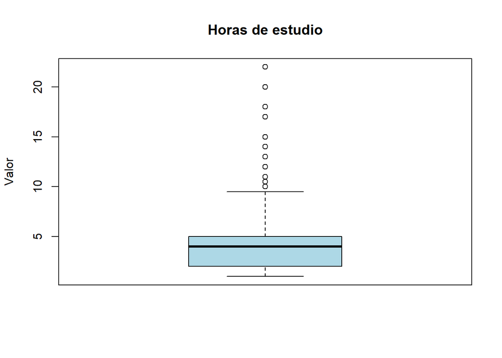

```r
analizar_variable <- function(Grupo5_renombrado, columna, titulo, color) {
  Q1 <- quantile(Grupo5_renombrado[[columna]], 0.25, na.rm = TRUE)
  Q3 <- quantile(Grupo5_renombrado[[columna]], 0.75, na.rm = TRUE)
  IQR <- Q3 - Q1

  limite_inferior <- Q1 - 1.5 * IQR
  limite_superior <- Q3 + 1.5 * IQR

  outliers <- Grupo5_renombrado[[columna]] < limite_inferior | Grupo5_renombrado[[columna]] > limite_superior

  print(paste("Posible outliers en", titulo, ":", sum(outliers, na.rm = TRUE)))

  boxplot(Grupo5_renombrado[[columna]],
          main = titulo,
          col = color,
          ylab = "Valor")
}

analizar_variable(Grupo5_renombrado,
                  "horas_estudio",
                  "Horas de estudio", "lightblue")
```

```
[1] "Posible outliers en Promedio ponderado : 158"
```

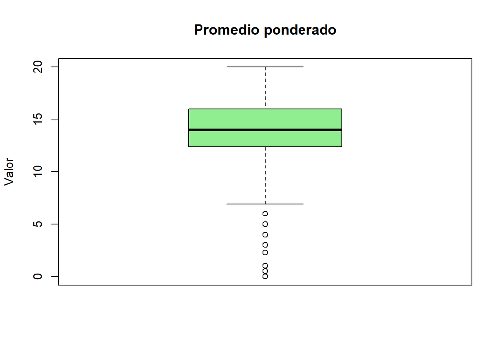

```r
analizar_variable(Grupo5_renombrado,
                  "promedio_ponderado",
                  "Promedio ponderado", "lightgreen")
```

```
[1] "Posible outliers en Horas de sueño : 91"
```

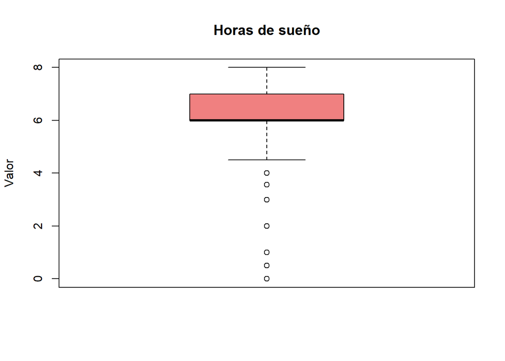

```r
analizar_variable(Grupo5_renombrado,
                  "horas_sueno",
                  "Horas de sueño", "lightcoral")
```

```
[1] "Posible outliers en Tiempo sin revisar el celular : 129"
```

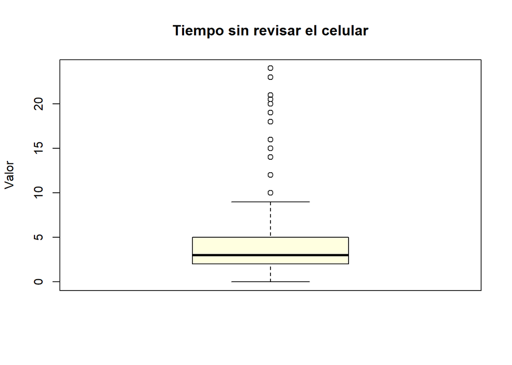

```r
analizar_variable(Grupo5_renombrado,
                  "tiempo_sin_revisar_el_celular",
                  "Tiempo sin revisar el celular", "lightyellow")
```

```r
nueva_data <- Grupo5_renombrado[-71, ]
```

## 12 5.4 Tipos de vareables

```r
Grupo5_renombrado$satisfaccion_social <- factor(Grupo5_renombrado$satisfaccion_social)
Grupo5_renombrado$satisfaccion_academica <- factor(Grupo5_renombrado$satisfaccion_academica)
Grupo5_renombrado$universidad <- factor(Grupo5_renombrado$universidad)
Grupo5_renombrado$tipo_contenido <- factor(Grupo5_renombrado$tipo_contenido)
```

```r
Grupo5_renombrado<- Grupo5_renombrado %>%
  mutate(promedio_ponderado = ifelse(promedio_ponderado == 0, NA, promedio_ponderado))
```

```r
glimpse(Grupo5_renombrado)
```

```
Rows: 1,307
Columns: 9
$ horas_estudio                 <dbl> 2.0, 2.0, 4.0, 3.5, 3.0, 1.5, 2.0, 4.0, …
$ promedio_ponderado            <dbl> 14.20, 17.00, 12.00, 15.90, 16.00, 16.17…
$ tiempo_sin_revisar_el_celular <dbl> 2.0, 5.3, 5.0, 1.5, 4.0, 1.0, 0.5, 12.0,…
$ horas_sueno                   <dbl> 8.0, 8.0, 6.0, 6.0, 5.0, 7.0, 7.0, 8.0, …
$ tipo_contenido                <fct> "Entretenimiento (ver videos, seguir dep…
$ satisfaccion_academica        <fct> 3, 3, 3, 4, 4, 3, 4, 4, 3, 3, 3, 3, 4, 3…
$ satisfaccion_social           <fct> 4, 3, 5, 5, 4, 3, 4, 4, 4, 5, 4, 5, 3, 4…
$ universidad                   <fct> Privada, Privada, Privada, Privada, Públ…
$ red_social_mas_usada          <fct> Whatsapp, Tiktok, Whatsapp, Whatsapp, Ti…
```

## 13 5.5 Normalizar

## 14 Horas de estudio

```r
Grupo5_renombrado %>%
  filter(horas_estudio>10) %>%
  select(c(2))
```

```
# A tibble: 35 × 1
   promedio_ponderado
                <dbl>
 1               15.2
 2               12
 3               19
 4                1
 5               15
 6               18
 7               15
 8               16.0
 9               15
10               13
# ℹ 25 more rows
```

```r
limite_inferior <- 0
limite_superior <- 8

nueva_data$horas_estudio <- ifelse(nueva_data$horas_estudio < limite_inferior | nueva_data$horas_estudio > limite_superior, NA, nueva_data$horas_estudio)

summary(nueva_data$horas_estudio)
```

```
   Min. 1st Qu.  Median    Mean 3rd Qu.    Max.    NA's
   1.00    2.00    3.50    3.71    5.00    8.00      75
```

```r
limite_inferior <- 0
limite_superior <- 30

nueva_data$tiempo_sin_revisar_el_celular <- pmin(pmax(nueva_data$tiempo_sin_revisar_el_celular, limite_inferior), limite_superior)

nueva_data$tiempo_sin_revisar_el_celular[nueva_data$tiempo_sin_revisar_el_celular < limite_inferior | nueva_data$tiempo_sin_revisar_el_celular > limite_superior] <- NA

summary(Grupo5_renombrado$tiempo_sin_revisar_el_celular)
```

```
   Min. 1st Qu.  Median    Mean 3rd Qu.    Max.
  0.000   2.000   3.000   4.658   5.000  24.000
```

```r
summary(nueva_data$tiempo_sin_revisar_el_celular)
```

```
   Min. 1st Qu.  Median    Mean 3rd Qu.    Max.
  0.000   2.000   3.000   4.659   5.000  24.000
```

## 16 Horas de sueño

```r
nueva_data$horas_sueno <- as.numeric(nueva_data$horas_sueno)

Grupo5_renombrado %>%
  filter(horas_sueno<2) %>%
  select(c(9))
```

```
# A tibble: 3 × 1
  red_social_mas_usada
  <fct>
1 Otro
2 Otro
3 Tiktok
```

```r
limite_inferior <- 2
limite_superior <- 8

nueva_data$horas_sueno[nueva_data$horas_sueno < limite_inferior] <- NA

nueva_data$horas_sueno <- pmin(nueva_data$horas_sueno, limite_superior)


summary(Grupo5_renombrado$horas_sueno)
```

```
   Min. 1st Qu.  Median    Mean 3rd Qu.    Max.
  0.000   6.000   6.000   6.248   7.000   8.000
```

```r
summary(nueva_data$horas_sueno)
```

```
   Min. 1st Qu.  Median    Mean 3rd Qu.    Max.    NA's
  2.000   6.000   6.000   6.261   7.000   8.000       3
```

## 17 Satisfaccion social

```r
summary(Grupo5_renombrado$satisfaccion_social)
```

```
  1   2   3   4   5
 39  65 333 532 338
```

```r
sum(is.na(nueva_data$satisfaccion_social))
```

```
[1] 0
```

## 18 Porcentajes de NA`S

```r
total_filas <- nrow(nueva_data)

tabla_na <- nueva_data %>%
  summarise(across(everything(), ~ sum(is.na(.)))) %>%
  pivot_longer(cols = everything(), names_to = "variable", values_to = "n_missings") %>%
  mutate(porcentaje = round(100 * n_missings / total_filas, 2))
tabla_na
```

```
# A tibble: 9 × 3
  variable                      n_missings porcentaje
  <chr>                              <int>      <dbl>
1 horas_estudio                         75       5.74
2 promedio_ponderado                     0       0
3 tiempo_sin_revisar_el_celular          0       0
4 horas_sueno                            3       0.23
5 tipo_contenido                         0       0
6 satisfaccion_academica                 4       0.31
7 satisfaccion_social                    0       0
8 universidad                            0       0
9 red_social_mas_usada                   0       0
```

```r
df_copia<-nueva_data
df<-nueva_data
df
```

```
# A tibble: 1,306 × 9
   horas_estudio promedio_ponderado tiempo_sin_revisar_el_celular horas_sueno
           <dbl>              <dbl>                         <dbl>       <dbl>
 1           2                 14.2                           2             8
 2           2                 17                             5.3           8
 3           4                 12                             5             6
 4           3.5               15.9                           1.5           6
 5           3                 16                             4             5
 6           1.5               16.2                           1             7
 7           2                 14.4                           0.5           7
 8           4                 13.6                          12             8
 9           3                 18                             3             6
10          NA                 18                             4             5
# ℹ 1,296 more rows
# ℹ 5 more variables: tipo_contenido <chr>, satisfaccion_academica <dbl>,
#   satisfaccion_social <dbl>, universidad <chr>, red_social_mas_usada <fct>
```

## 19 6. Analisis y conclusiones de los objetibos mediante descriptores y graficos

## 20 6.1 Estudiar la relación entre frecuencia de revisión de redes sociales y el tiempo promedio de atención sostenida

### 20.1 Revisión de redes sociales al día

```r
datos <- DF %>%
  filter(`Grupo de la sección 5 que realiza la encuesta.` == "Grupo 5") %>%
  select(
    tiempo_sin_revisar_el_celular = `13. ¿Cuál es el tiempo máximo que puedes estar sin revisar tus redes sociales?`,
    revisiones_diarias = `14. ¿Cuántas veces al día aproximadamente revisas tu teléfono por notificaciones de redes sociales mientras estudias?`
  ) %>%
  mutate(
    tiempo_sin_revisar_el_celular = as.numeric(tiempo_sin_revisar_el_celular),
    revisiones_diarias = as.numeric(revisiones_diarias)
  ) %>%
  filter(
    revisiones_diarias >= 0 & revisiones_diarias <= 60,
    tiempo_sin_revisar_el_celular >= 0 & tiempo_sin_revisar_el_celular <= 8
  )


summary(datos)
```

```
 tiempo_sin_revisar_el_celular revisiones_diarias
 Min.   :0.250                 Min.   : 0.0
 1st Qu.:2.000                 1st Qu.: 4.0
 Median :3.000                 Median : 8.0
 Mean   :3.308                 Mean   : 8.3
 3rd Qu.:5.000                 3rd Qu.:10.0
 Max.   :8.000                 Max.   :30.0
```

```r
cat("Moda tiempo_sin_revisar_el_celular:", mfv(datos$tiempo_sin_revisar_el_celular, na_rm = TRUE), "\n")
```

```
Moda tiempo_sin_revisar_el_celular: 2
```

```r
cat("Moda revisiones_diarias:", mfv(datos$revisiones_diarias, na_rm = TRUE), "\n")
```

```
Moda revisiones_diarias: 10
```

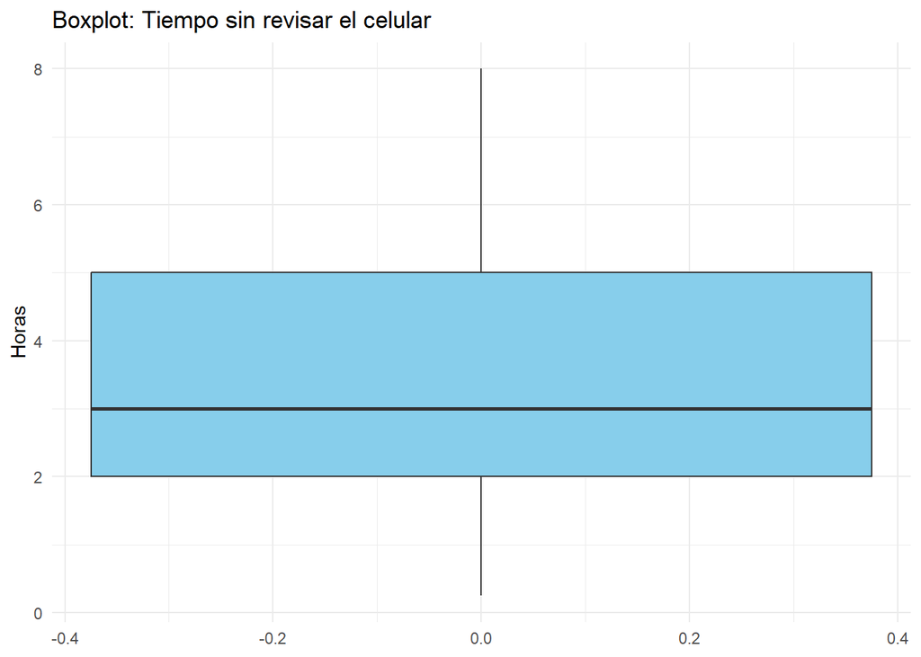

```r
ggplot(datos, aes(y = tiempo_sin_revisar_el_celular)) +
  geom_boxplot(fill = "skyblue") +
  labs(title = "Boxplot: Tiempo sin revisar el celular", y = "Horas") +
  theme_minimal()
```

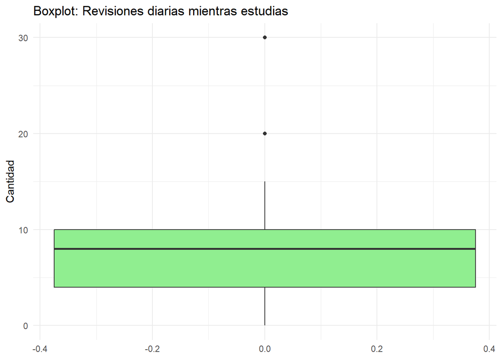

```r
ggplot(datos, aes(y = revisiones_diarias)) +
  geom_boxplot(fill = "lightgreen") +
  labs(title = "Boxplot: Revisiones diarias mientras estudias", y = "Cantidad") +
  theme_minimal()
```

### 20.2 6.1.1 Descriptores

```r
#desviacion estandar de revisiones diarias
sd_revisiones <- sd(datos$revisiones_diarias)
ric_revisiones <- IQR(datos$revisiones_diarias)
#desviacion estandar de tiempo sin revisar el celular
sd_tiempo <- sd(datos$tiempo_sin_revisar_el_celular)
ric_tiempo <- IQR(datos$tiempo_sin_revisar_el_celular)

cat("Revisiones diarias:\n")
```

```
Revisiones diarias:
```

```r
cat("  Desviación estándar:", round(sd_revisiones, 2), "\n")
```

```
  Desviación estándar: 5.6
```

```r
cat("  Rango intercuartílico (RIC):", round(ric_revisiones, 2), "\n\n")
```

```
  Rango intercuartílico (RIC): 6
```

```r
cat("Tiempo sin revisar el celular:\n")
```

```
Tiempo sin revisar el celular:
```

```r
cat("  Desviación estándar:", round(sd_tiempo, 2), "\n")
```

```
  Desviación estándar: 1.91
```

```r
cat("  Rango intercuartílico (RIC):", round(ric_tiempo, 2), "\n")
```

```
  Rango intercuartílico (RIC): 3
```

### 20.3 6.1.2 Graficos

Hay pocas personas que revisan redes sociales muchas veces, pero esas pocas elevan la dispersión

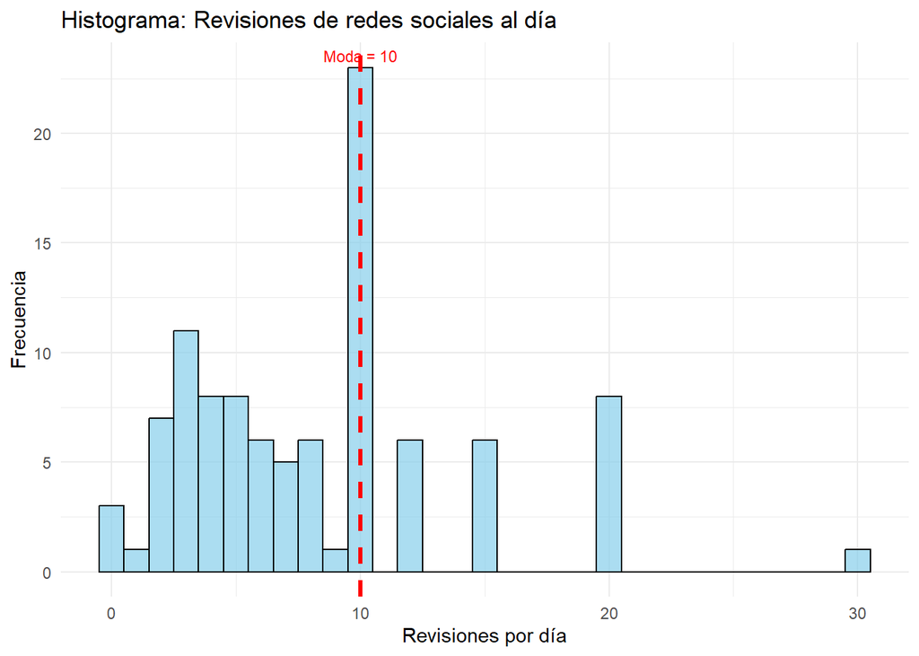

```r
ggplot(datos, aes(x = revisiones_diarias)) +
  geom_histogram(binwidth = 1, fill = "skyblue", color = "black", alpha = 0.7) +
  geom_vline(xintercept = 10, color = "red", linetype = "dashed", size = 1.2) +  # Línea en la moda
  annotate("text", x = 10, y = max(table(cut(datos$revisiones_diarias, breaks = seq(0, max(datos$revisiones_diarias), by = 1)))),
           label = "Moda = 10", vjust = -0.5, color = "red", size = 3) +  # Etiqueta
  labs(
    title = "Histograma: Revisiones de redes sociales al día",
    x = "Revisiones por día",
    y = "Frecuencia"
  ) +
  theme_minimal()
```

El gráfico de dispersión permite observar la relación entre la cantidad de revisiones diarias del celular y el tiempo que una persona puede permanecer sin revisarlo. Visualmente, se aprecia una posible tendencia negativa: a mayor número de revisiones diarias, menor es el tiempo de atención sostenida.

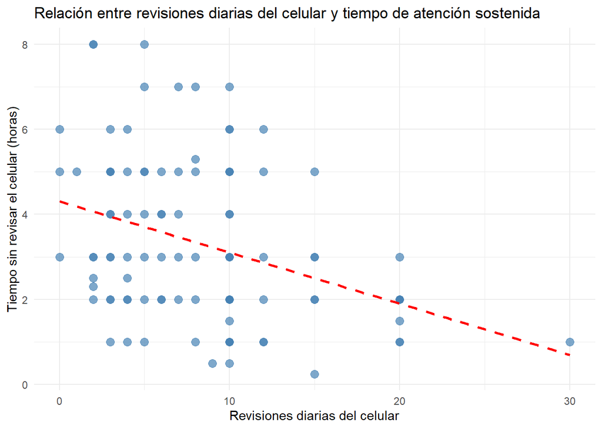

```r
ggplot(datos, aes(x = revisiones_diarias, y = tiempo_sin_revisar_el_celular)) +
  geom_point(color = "steelblue", size = 3, alpha = 0.7) +
  geom_smooth(method = "lm", se = FALSE, color = "red", linetype = "dashed") +
  labs(
    title = "Relación entre revisiones diarias del celular y tiempo de atención sostenida",
    x = "Revisiones diarias del celular",
    y = "Tiempo sin revisar el celular (horas)"
  ) +
  theme_minimal()
```

REGRESIÓN LINEAL

tiempo_sin_revisar_el_celular=4.307−0.120⋅revisiones_diarias

## 21 6.2 Evaluar si existe una diferencia en el desempeño académico entre las personas que duermen más y las que duermen menos.

```r
df<-Grupo5_renombrado
```

```r
df <- df %>%
  filter(!is.na(promedio_ponderado), !is.na(horas_sueno))
```

### 21.1 6.2.1 Descriptores para Horas de Estudio

```r
media_estudio <- mean(df$horas_estudio, na.rm = TRUE)
mediana_estudio <- median(df$horas_estudio, na.rm = TRUE)

cv_estudio <- sd(df$horas_estudio, na.rm = TRUE) / media_estudio

IQR_estudio <- IQR(df$horas_estudio, na.rm = TRUE)

cat("Media de Horas de Estudio: ", media_estudio, "\n")
```

```
Media de Horas de Estudio:  4.185971
```

```r
cat("Mediana de Horas de Estudio: ", mediana_estudio, "\n")
```

```
Mediana de Horas de Estudio:  4
```

```r
cat("Coeficiente de Variación: ", cv_estudio, "\n")
```

```
Coeficiente de Variación:  0.6394412
```

```r
cat("Rango Intercuartílico (IQR): ", IQR_estudio, "\n")
```

```
Rango Intercuartílico (IQR):  3
```

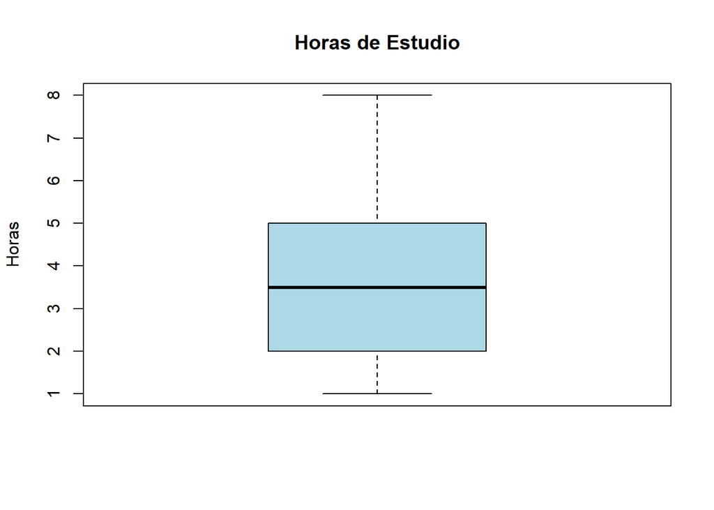

```r
boxplot(nueva_data$horas_estudio, main="Horas de Estudio", ylab="Horas", col="lightblue")
```

### 21.2 6.2.2 Descriptores para Promedio Ponderado

```r
media_promedio <- mean(df$promedio_ponderado, na.rm = TRUE)
mediana_promedio <- median(df$promedio_ponderado, na.rm = TRUE)

cv_promedio <- sd(df$promedio_ponderado, na.rm = TRUE) / media_promedio

IQR_promedio <- IQR(df$promedio_ponderado, na.rm = TRUE)

cat("Media del Promedio Ponderado: ", media_promedio, "\n")
```

```
Media del Promedio Ponderado:  14.44294
```

```r
cat("Mediana del Promedio Ponderado: ", mediana_promedio, "\n")
```

```
Mediana del Promedio Ponderado:  14.7
```

```r
cat("Coeficiente de Variación: ", cv_promedio, "\n")
```

```
Coeficiente de Variación:  0.1693723
```

```r
cat("Rango Intercuartílico (IQR): ", IQR_promedio, "\n")
```

```
Rango Intercuartílico (IQR):  3
```

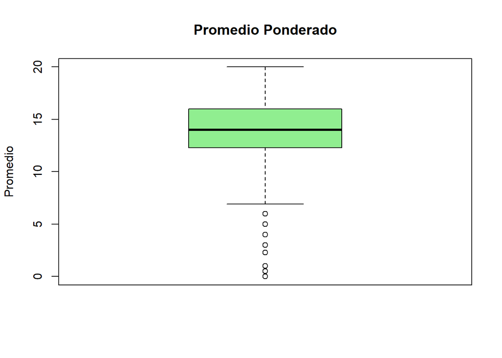

```r
boxplot(nueva_data$promedio_ponderado, main="Promedio Ponderado", ylab="Promedio", col="lightgreen")
```

### 21.3 6.2.3 Graficos para Horas de sueño

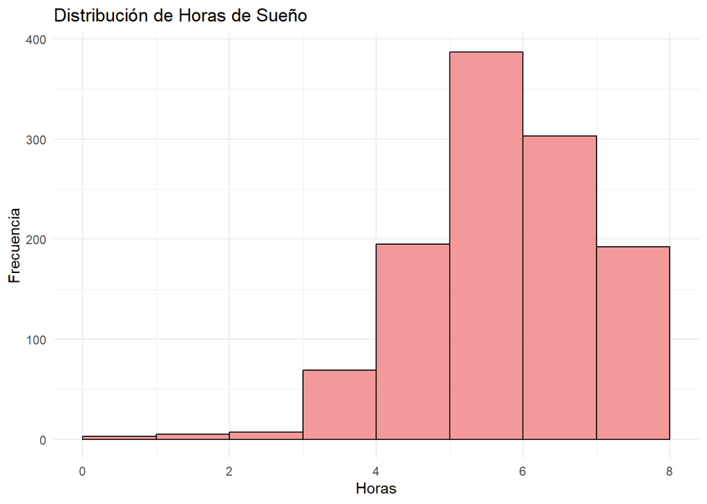

```r
ggplot(df, aes(x = horas_sueno)) +
  geom_histogram(binwidth = 1, fill = "lightcoral", color = "black", alpha = 0.8, boundary = 0) +
  labs(title = "Distribución de Horas de Sueño",
       x = "Horas", y = "Frecuencia") +
  theme_minimal()
```

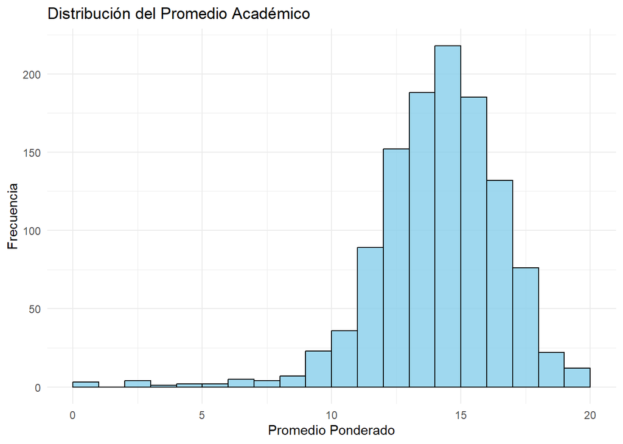

```r
ggplot(Grupo5_renombrado, aes(x = promedio_ponderado)) +
  geom_histogram(binwidth = 1, fill = "skyblue", color = "black", alpha = 0.8, boundary = 0) +
  labs(title = "Distribución del Promedio Académico",
       x = "Promedio Ponderado", y = "Frecuencia") +
  theme_minimal()
```

### 21.4 6.2.4 Tabla de Sueño

```r
df <- df %>%
  mutate(grupo_sueno = case_when(
    horas_sueno <= 6 ~ "Poco sueño",
    horas_sueno > 6 ~ "Más sueño"
  ))
```

```r
# Tabla resumen descriptiva en formato vertical
df %>%
  group_by(grupo_sueno) %>%
  summarise(
    Mínimo = min(promedio_ponderado, na.rm = TRUE),
    Q1 = quantile(promedio_ponderado, 0.25, na.rm = TRUE),
    Mediana = median(promedio_ponderado, na.rm = TRUE),
    Media = mean(promedio_ponderado, na.rm = TRUE),
    Q3 = quantile(promedio_ponderado, 0.75, na.rm = TRUE),
    Máximo = max(promedio_ponderado, na.rm = TRUE),
    Desviación = sd(promedio_ponderado, na.rm = TRUE),
    n = n()
  ) %>%
  pivot_longer(cols = -grupo_sueno, names_to = "Estadística", values_to = "Valor") %>%
  pivot_wider(names_from = grupo_sueno, values_from = Valor)
```

```
# A tibble: 8 × 3
  Estadística `Más sueño` `Poco sueño`
  <chr>             <dbl>        <dbl>
1 Mínimo             0.5          2.3
2 Q1                13.2         13
3 Mediana           15           14.5
4 Media             14.6         14.3
5 Q3                16           16
6 Máximo            20           20
7 Desviación         2.61         2.31
8 n                495          666
```

### 21.5 6.2.5 Analisis bivariado de Sueño vs Promedio Academico

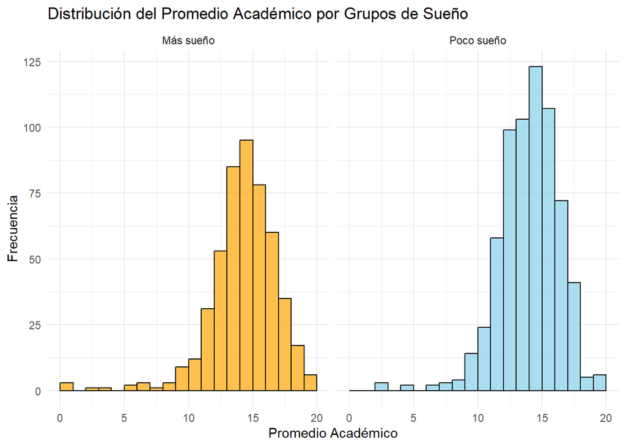

```r
ggplot(df, aes(x = promedio_ponderado, fill = grupo_sueno)) +
  geom_histogram(binwidth = 1, alpha = 0.7, position = "identity", color = "black", boundary = 0) +
  facet_wrap(~grupo_sueno) +
  labs(title = "Distribución del Promedio Académico por Grupos de Sueño",
       x = "Promedio Académico", y = "Frecuencia") +
  theme_minimal() +
  scale_fill_manual(values = c("Poco sueño" = "skyblue", "Más sueño" = "orange")) +
  theme(legend.position = "none")
```

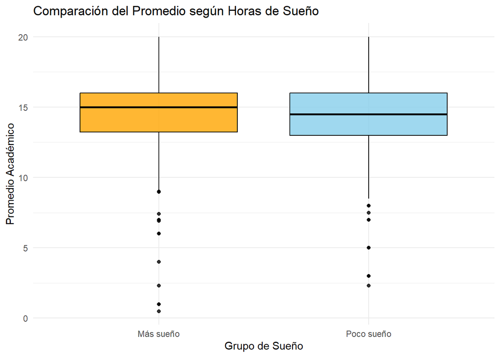

```r
ggplot(df, aes(x = grupo_sueno, y = promedio_ponderado, fill = grupo_sueno)) +
  geom_boxplot(alpha = 0.8, color = "black") +
  labs(title = "Comparación del Promedio según Horas de Sueño",
       x = "Grupo de Sueño", y = "Promedio Académico") +
  theme_minimal() +
  scale_fill_manual(values = c("Poco sueño" = "skyblue", "Más sueño" = "orange")) +
  theme(legend.position = "none")
```

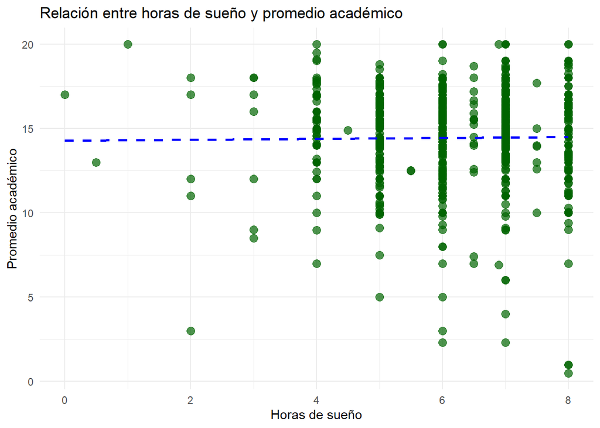

```r
ggplot(df, aes(x = horas_sueno, y = promedio_ponderado)) +
  geom_point(color = "darkgreen", size = 3, alpha = 0.7) +  # puntos
  geom_smooth(method = "lm", se = FALSE, color = "blue", linetype = "dashed") +  # línea de regresión
  labs(
    title = "Relación entre horas de sueño y promedio académico",
    x = "Horas de sueño",
    y = "Promedio académico"
  ) +
  theme_minimal()
```

```r
correlacion <- cor(df$horas_sueno, df$promedio_ponderado, use = "complete.obs", method = "pearson")
print(correlacion)
```

```
[1] 0.01301405
```

### 21.6 6.2.6 Conclusion

Según el análisis realizado podemos decir que no se encontró una relación clara entre las horas de sueño y el rendimiento académico. El coeficiente de correlación de pearson fue de 0.01301405, un número muy cercano a cero, lo que indica que prácticamente no hay conexión entre cuánto duermen los estudiantes y sus notas. Aunque en los gráficos se notan algunas diferencias en los promedios y una ligera variación en los resultados, no hay una tendencia clara que indique que dormir más o menos influya directamente en el desempeño académico. En resumen, esto sugiere que el rendimiento de los estudiantes depende de otros factores además del sueño.

## 22 6.3 Evaluar el desempeño académico de los estudiantes con respecto al tipo de contenido que consumen.

### 22.1 6.3.1 Descriptores y graficos

#### 22.1.1 6.3.1.1 Promedio ponderado

```r
media_prom <- mean(df$promedio_ponderado, na.rm = TRUE)  # Media
mediana_prom <- median(df$promedio_ponderado, na.rm = TRUE)  # Mediana
sd_prom <- sd(df$promedio_ponderado, na.rm = TRUE)  # Desviación estándar
min_prom <- min(df$promedio_ponderado, na.rm = TRUE)  # Mínimo
max_prom <- max(df$promedio_ponderado, na.rm = TRUE)  # Máximo
iqr_prom <- IQR(df$promedio_ponderado, na.rm = TRUE)  # Rango intercuartílico (IQR)
q1_prom <- quantile(df$promedio_ponderado, 0.25, na.rm = TRUE)  # Primer cuartil (Q1)
q3_prom <- quantile(df$promedio_ponderado, 0.75, na.rm = TRUE)  # Tercer cuartil (Q3)

cat("Media de Promedio ponderado:", round(media_prom,2), "\n")
```

```
Media de Promedio ponderado: 14.44
```

```r
cat("Mediana de Promedio ponderado:", round(mediana_prom,2), "\n")
```

```
Mediana de Promedio ponderado: 14.7
```

```r
cat("Desviación estándar de Promedio ponderado:", round(sd_prom,2), "\n")
```

```
Desviación estándar de Promedio ponderado: 2.45
```

```r
cat("Mínimo de Promedio ponderado:", round(min_prom,2), "\n")
```

```
Mínimo de Promedio ponderado: 0.5
```

```r
cat("Máximo de Promedio ponderado:", round(max_prom,2), "\n")
```

```
Máximo de Promedio ponderado: 20
```

```r
cat("Rango intercuartílico (IQR) de Promedio ponderado:", round(iqr_prom,2), "\n")
```

```
Rango intercuartílico (IQR) de Promedio ponderado: 3
```

```r
cat("Primer cuartil (Q1) de Promedio ponderado:", round(q1_prom,2), "\n")
```

```
Primer cuartil (Q1) de Promedio ponderado: 13
```

```r
cat("Tercer cuartil (Q3) de Promedio ponderado:", round(q3_prom,2), "\n")
```

```
Tercer cuartil (Q3) de Promedio ponderado: 16
```

```
[1] "Posible outliers en Promedio ponderado : 158"
```

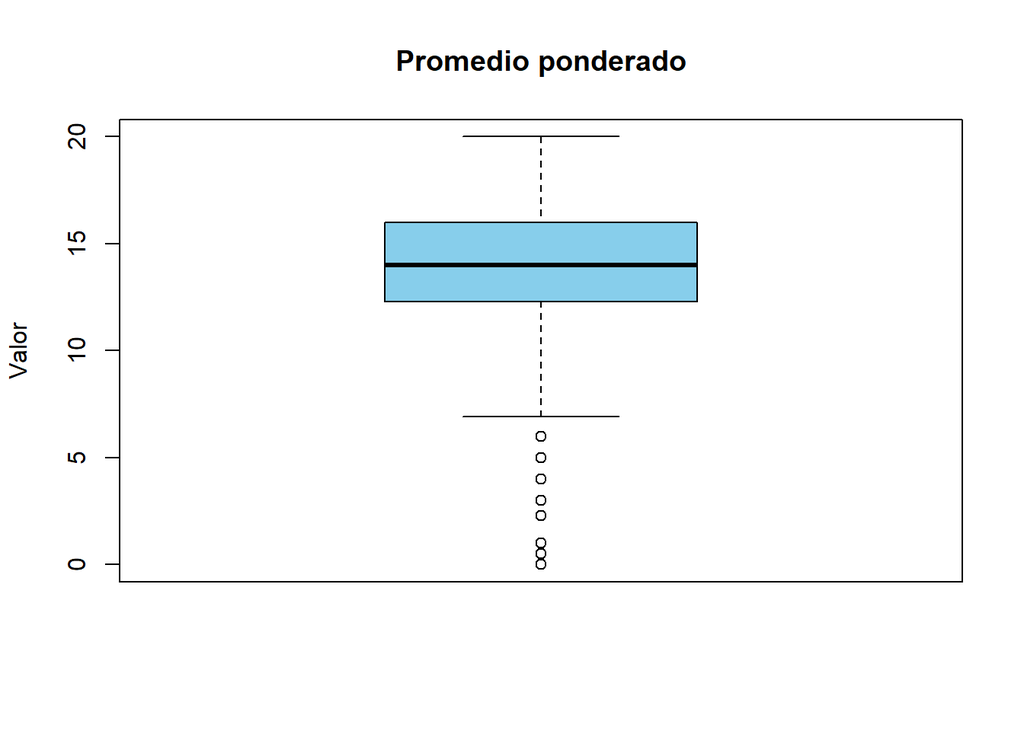

```r
#Grafica

analizar_variable <- function(data, columna, titulo, color) {
  Q1 <- quantile(data[[columna]], 0.25, na.rm = TRUE)
  Q3 <- quantile(data[[columna]], 0.75, na.rm = TRUE)
  IQR <- Q3 - Q1

  limite_inferior <- Q1 - 1.5 * IQR
  limite_superior <- Q3 + 1.5 * IQR

  outliers <- data[[columna]] < limite_inferior | data[[columna]] > limite_superior

  print(paste("Posible outliers en", titulo, ":", sum(outliers, na.rm = TRUE)))

  boxplot(data[[columna]],
          main = titulo,
          col = color,
          ylab = "Valor")
}

analizar_variable(nueva_data,
                  "promedio_ponderado",
                  "Promedio ponderado", "skyblue")
```

#### 22.1.2 6.3.1.2 Tipo de contenido consumido

```r
# Frecuencias absolutas de cada tipo de contenido
frecuencias <- table(Data_5$`16. ¿Qué tipo de contenido consumes principalmente en redes sociales?`)

frecuencias_relativas <- prop.table(frecuencias)

porcentajes <- frecuencias_relativas * 100

# Tabla combinada
tabla_resumen <- data.frame(
  Tipo_de_Contenido = names(frecuencias),
  Frecuencia_Absoluta = as.integer(frecuencias),
  Frecuencia_Relativa = frecuencias_relativas,
  Porcentaje = paste0(round(porcentajes, 2), "%"),
  row.names = NULL
)

# Mostrar la tabla
cat("Tabla de Frecuencias:\n")
```

```
Tabla de Frecuencias:
```

```r
print(tabla_resumen)
```

```
                                               Tipo_de_Contenido
1                                Educación (contenido académico)
2 Entretenimiento (ver videos, seguir deportes, escuchar música)
3                            Información (noticias , actualidad)
4                                                     Socializar
  Frecuencia_Absoluta
1                 127
2                 926
3                 152
4                 102
                                        Frecuencia_Relativa.Var1
1                                Educación (contenido académico)
2 Entretenimiento (ver videos, seguir deportes, escuchar música)
3                            Información (noticias , actualidad)
4                                                     Socializar
  Frecuencia_Relativa.Freq Porcentaje
1               0.09716909      9.72%
2               0.70849273     70.85%
3               0.11629686     11.63%
4               0.07804132       7.8%
```

```r
#La moda
moda <- tabla_resumen$Tipo_de_Contenido[which.max(tabla_resumen$Frecuencia_Absoluta)]
cat("\nModa (categoría más frecuente):\n")
```

```
Moda (categoría más frecuente):
```

```r
cat(moda, "\n")
```

```
Entretenimiento (ver videos, seguir deportes, escuchar música)
```

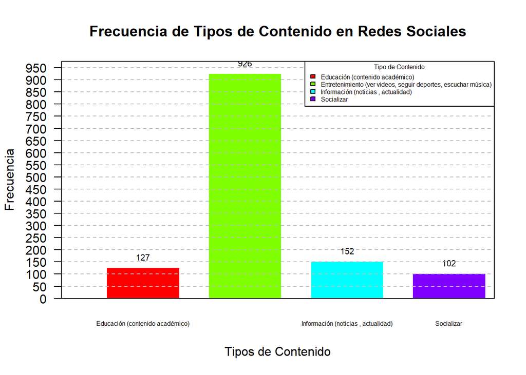

```r
#Grafica tipo_contenido

frecuencias <- table(Data_5$'16. ¿Qué tipo de contenido consumes principalmente en redes sociales?')

# Colores únicos para cada barra
colores <- rainbow(length(frecuencias))  # Genera colores distintos para cada barra

# Grafico de barras
barplot_heights <- barplot(frecuencias,
                          col = colores,
                          main = "Frecuencia de Tipos de Contenido en Redes Sociales",
                          xlab = "Tipos de Contenido",
                          ylab = "Frecuencia",
                          border = "white",
                          las = 1,
                          cex.names = 0.5,
                          cex.axis = 0.7,
                          xlim = c(0, length(frecuencias) + 1.5),
                          ylim = c(0, max(frecuencias) + 50),
                          yaxt = "n",
                          space = 0.4)

# Valores de frecuencia encima de cada barra
text(x = barplot_heights,
     y = frecuencias,
     labels = frecuencias,
     pos = 3,
     cex = 0.7)

# Líneas horizontales en el gráfico
abline(h = seq(0, max(frecuencias) + 50, by = 50), col = "gray", lty = 2)

axis(2, at = seq(0, max(frecuencias) + 50, by = 50), las = 1)


# Leyenda
legend("topright",
       legend = names(frecuencias),
       fill = colores,
       title = "Tipo de Contenido",
       cex = 0.5)

# Marco
box()
```